```python
%matplotlib notebook
import numpy as np
from pandas import Series
from numpy import array, dot, sin, cos, pi, exp
from scipy.linalg import solve_banded
import matplotlib.pyplot as plt
from mpl_toolkits.mplot3d import Axes3D
from matplotlib import rc
rc('font',**{'family':'sans-serif','sans-serif':['Helvetica']})
rc('text', usetex=True)
np.set_printoptions(
    precision=4, suppress=True)
```

# Методы решения начально-краевых задач для гиперболических уравнений

## Постановка задачи

Рассмотриваем задачу о колебании струны с заданной динамикой на концах, а также с заданными начальным отклонением и скоростью:

$$ \frac{\partial^2 u}{\partial t^2} = a^2 \frac{\partial^2 u}{\partial x^2} + f(x, t), \text{ }x\in(0; l),\text{ }t > 0,\\ u\rvert_{t=0}=\varphi(x),\text{ }\frac{\partial u}{\partial t}\Big\rvert_{t=0}=\psi(x),\\ u\rvert_{x=0}=\mu_1(t),\text{ }u\rvert_{x=l}=\mu_2(t).$$

В нашем случае задача имеет следующий вид (концы закреплены):

$$ \frac{\partial^2 u}{\partial t^2} = \frac{\partial^2 u}{\partial x^2} + 2 e^{-3t} \sin{\pi x}, \text{ }x\in(0; 1),\text{ }t > 0,\\ u\rvert_{t=0}=-4 \sin{2\pi x}+2-3x,\text{ }\frac{\partial u}{\partial t}\Big\rvert_{t=0}=2\pi\sin{2\pi x},\\ u\rvert_{x=0}=2,\text{ }u\rvert_{x=1}=-1.$$

```python
a, l, T = 1, 1, 1
f   = lambda x, t: 2*exp(-3*t) * sin(pi*x)
phi = lambda x: -4*sin(2*pi*x) + 2 - 3*x
psi = lambda x: 2*pi*sin(2*pi*x)
mu1 = lambda t: 2
mu2 = lambda t: -1
```

## Точное решение методом Фурье

Как и в случае с параболическими уравнениями, искать решение будем в виде ряда Фурье по собственным функциям задачи Штурма-Лиувилля, но прежде сведём задачу к задаче с однородными краевыми условиями заменой $u=v+2-3x$. Прийдём к следующей задаче:

$$ \frac{\partial^2 v}{\partial t^2} = \frac{\partial^2 v}{\partial x^2} + 2 e^{-3t} \sin{\pi x}, \text{ }x\in(0; 1),\text{ }t > 0,\\ v\rvert_{t=0}=-4 \sin{2\pi x},\text{ }\frac{\partial v}{\partial t} \Big\rvert_{t=0}=2\pi\sin{2\pi x},\\ v\rvert_{x=0}=0,\text{ }v\rvert_{x=1}=0.$$

Итак, $v(x, t)=\sum\limits_{n=1}^{\infty} c_n(t) \sin{\pi n x}$, систему собственных функций выбрали из удобства. Потребуем, чтобы функция $v$ удовлетворяла начальным условиям:

$$ v\rvert_{t=0}=\sum\limits_{n=1}^{\infty} c_n(0) \sin{\pi n x}=-4\sin{2\pi x}\Rightarrow c_2(0)=-4,\text{ }\forall n\neq2\text{ }c_n(0)=0;$$$$ \frac{\partial v}{\partial t}\Big\rvert_{t=0}=\sum\limits_{n=1}^{\infty} c_n'(0) \sin{\pi n x}=2\pi\sin{2\pi x}\Rightarrow c_2'(0)=2\pi,\text{ }\forall n\neq2\text{ }c_n'(0)=0.$$

Теперь потребуем, чтобы $v$ удовлетворяла самому диф. уравнению.

$$ \frac{\partial^2 v}{\partial t^2} - \frac{\partial^2 v}{\partial x^2} \equiv \sum\limits_{n=1}^{\infty}\left[ c_n''(t) + \pi^2n^2c_n(t)\right]\sin{\pi n x} = 2e^{-3t}\sin{\pi x}. $$

Отсюда следует 2 вещи: $c_1''(t) + \pi^2c_1(t)=2e^{-3t}$ и $\forall n>1\text{ }c_n''(t) + \pi^2n^2c_n(t)=0$.

С учётом сформированных нами выше начальных условий, решения всех этих начальных задач для ОДУ такие:

$$c_1(t)=\frac{1}{9+\pi^2}\left(-2\cos{\pi t} + \frac{6}{\pi}\sin{\pi t} + 2e^{-3t}\right),$$$$c_2(t)=-4\cos{2\pi t} + \sin{2\pi t},\text{ }\forall n>2\text{ } c_n(t)\equiv0.$$

Теперь

$$v(x, t)=\frac{\sin{\pi x}}{9+\pi^2}\left(-2\cos{\pi t} + \frac{6}{\pi}\sin{\pi t} + 2e^{-3t}\right) -4\cos{2\pi t} + \sin{2\pi t}\sin{2\pi x},$$

и, окончательно,

$$u(x, t)=\frac{\sin{\pi x}}{9+\pi^2}\left(-2\cos{\pi t} + \frac{6}{\pi}\sin{\pi t} + 2e^{-3t}\right) -4\cos{2\pi t} + \sin{2\pi t}\sin{2\pi x}+2-3x.$$

```python
def u_true(x, t):
    return (2 - 3*x +
            sin(2*pi*x) * (sin(2*pi*t) - 4*cos(2*pi*t)) +
            sin(pi*x)/(9+pi**2)*(-2*cos(pi*t)+6/pi*sin(pi*t)+2*exp(-3*t)))
```

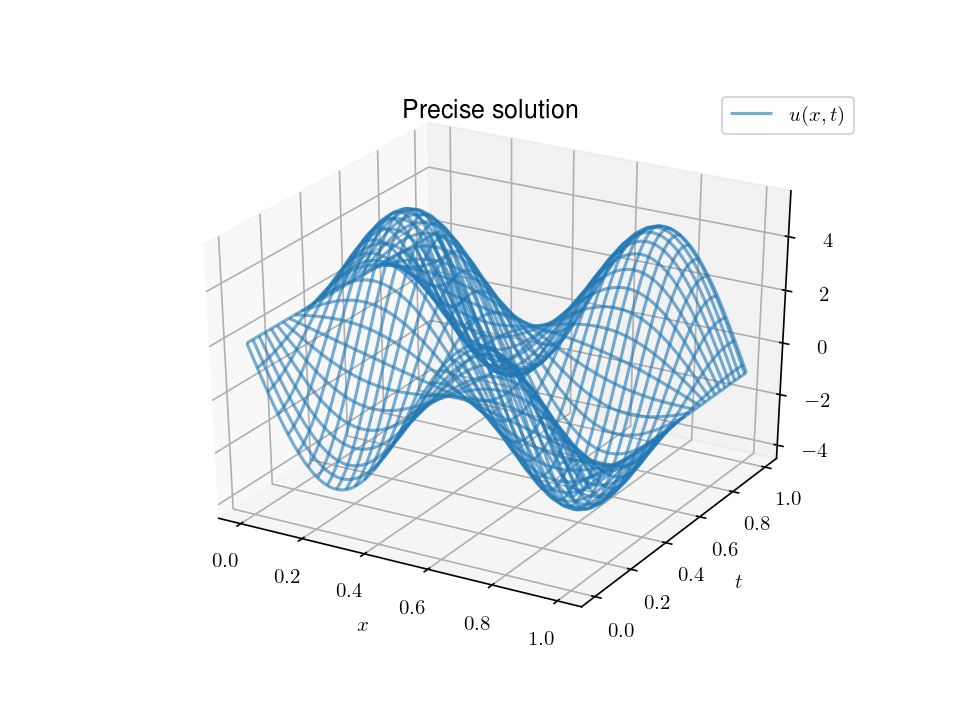

```python
x_dense = np.linspace(0, l, 101)
t_dense = np.linspace(0, T, 101)
xx_dense, tt_dense = np.meshgrid(x_dense, t_dense)

fig0 = plt.figure()
ax1 = fig0.add_subplot(111, projection='3d')
ax1.plot_wireframe(xx_dense, tt_dense, u_true(xx_dense, tt_dense), alpha=0.6, label='$u(x, t)$')
ax1.set_xlabel('$x$'); ax1.set_ylabel('$t$')
ax1.set_title("Precise solution")
ax1.legend();
```

```python
def plot_solution(uu, xx, tt, u_true, method_name, ics_appr_name):
    global xx_dense, tt_dense
    h = xx[0, 1] - xx[0, 0]
    tau = tt[1, 0] - tt[0, 0]
    fig = plt.figure(figsize=(9, 4))
    ax1 = fig.add_subplot(121, projection='3d')
    ax1.plot_wireframe(xx_dense, tt_dense, u_true(xx_dense, tt_dense), alpha=0.6, label='$u(x, t)$')
    ax1.plot_wireframe(xx, tt, uu, alpha=0.75, color='r',
                       label='$\hat{u}(x, t), h=%.2f, \\tau=%.2f$' % (h, tau))
    ax1.scatter(xx, tt, uu, alpha=0.75, s=10, c='r')
    ax1.set_title('%s method, %s for ics' % (method_name, ics_appr_name))

    ax2 = fig.add_subplot(122, projection='3d')
    ax2.plot_wireframe(xx, tt, np.abs(uu - u_true(xx, tt)),
                       label='$|\hat{u} - u|, h=%.2f, \\tau=%.2f$' % (h, tau))
    ax2.set_title('Error of solution')

    for ax in fig.get_axes():
        ax.set_xlabel('$x$'); ax.set_ylabel('$t$')
        ax.legend(loc=3);

    fig.tight_layout()
    return fig
```

## Сеточные методы

В целом всё аналогично сеточным методам для задач для параболических уравнений. Сложнее добиться второго порядка аппроксимации по $\tau$.

Число Курранта $\gamma=\frac{a^2\tau^2}{h^2}=\frac{1}{4}$.

```python
h, tau = 0.1, 0.05
gamma = a**2 * tau**2 / h**2
print('gamma = %.4f' %gamma)
Nx, Nt = int(l/h), int(T/tau)
x = np.linspace(0, l, Nx+1)
t = np.linspace(0, T, Nt+1)
xx, tt = np.meshgrid(x, t)
ff = f(xx, tt)
uu = np.zeros_like(ff)
```

```
gamma = 0.2500
```

На границах области используем краевые условия. В нашем случае для всех $k$ $u_0^k=2$, $u_10^k=-1$.

```python
uu[:, 0] = mu1(t); uu[:, -1] = mu2(t)
```

### Аппроксимация первых слоёв

Поскольку нам заданы два начальных условия, мы можем заполнить первые два временных слоя, которые будем использовать для "разгонки" разностной схемы. Более того, они нужны нам, чтобы была возможность аппроксимировать вторую производную функции по времени с помощью классической разностной схемы 2-го порядка.

Нулевой слой ($t=0$), очевидно, точно заполняется исходя из условия для начального отклонения: $\forall i\in\{0, 1, ..., N_x\}\text{ }u_i^0=\varphi_i$. В нашем случае $u_i^0=-4 \sin{2\pi x_i}+2-3x_i, i=0,...,10.$

```python
uu[0] = phi(x)
```

Более интересным является вопрос аппроксимации первого слоя с использованием условия для начальной скорости. Заметим, что нашей целью является выбор такого начального приближения, чтобы порядок аппроксимации был не меньше порядка аппроксимации самого ДУ на следующих слоях, чтобы не испортить качество работы метода. Заполнять будем лишь во внутренних точках отрезка, так как на границах уже заданы краевые условия.

#### 1-й способ: двухслойная разностная схема ($O(\tau)$)

Воспользуемся двухслойной разностной схемой, довольно стандартной для аппроксимации первой производной:

$$ \frac{u_i^1-u_i^0}{\tau}=\frac{\partial u}{\partial t}\Big\rvert_i^0 + O(\tau), \text{ }i\in\{1, ..., N_x-1\}.$$

Отбросив слагаемое $O(\tau)$, можем приближённо записать

$$ u_i^1 = u_i^0 + \tau \frac{\partial u}{\partial t}\Big\rvert_i^0=\varphi_i+\tau\psi_i\text{ }i\in\{1, ..., N_x-1\}.$$

Способ нежелателен, если схема для аппроксимации самого уравнения имеет 2-й порядок относительно $\tau$.

В нашем случае $u_i^1 = u_i^0 + 0,1\pi \sin{2\pi x_i}, i=1,...,9.$

```python
u11 = phi(x) + tau*psi(x)
```

```python
u11
```

```
array([ 2.    , -0.4665, -2.1054, -2.4054, -1.3665,  0.5   ,  2.3665,
        3.4054,  3.1054,  1.4665, -1.    ])
```

#### 2-й способ: двухслойная разностная схема с использованием самого уравнения ($O(\tau^2)$)

Воспользуемся всё тем же разностным шаблоном, только теперь разложим $u_i^1=u(x_i, \tau)$ по формуле Тейлора в окрестности точки $(x_i, 0)$ для каждого внутреннего узла 1-го слоя. Имеем:

$$\frac{u_i^1-u_i^0}{\tau}= \frac{u_i^0+\tau\frac{\partial u}{\partial t}\Big\rvert_i^0+ \frac{\tau^2}{2}\frac{\partial^2u}{\partial t^2}\Big\rvert_i^0+O(\tau^3)-u_i^0}{\tau}=\\ =\frac{\partial u}{\partial t}\Big\rvert_i^0 + \frac{\tau}{2}\frac{\partial^2u}{\partial t^2}\Big\rvert_i^0 + O(\tau^2).$$

Но давайте взглянем на наше уравнение (а также на 1-е начальное условие):

$$\frac{\partial^2u}{\partial t^2}\Big\rvert_i=a^2\frac{\partial^2 u}{\partial x^2}\Big\rvert_i^0+f_i^0=a^2\varphi''_i+f_i^0.$$

Теперь, отбрасывая слагаемое $O(\tau^2)$, можем приближённо записать:

$$\frac{u_i^1-u_i^0}{\tau}=\psi_i+\frac{\tau}{2}(a^2\varphi''_i+f_i^0)\Rightarrow\\ u_i^1 = \varphi_i + \tau\psi_i + \frac{\tau^2}{2}(a^2\varphi''_i + f_i^0),\text{ }i\in\{1, ..., N_x-1\}.$$

Этот способ уже, в отличие от предыдущего, даёт 2-й порядок аппроксимации по $\tau$ и позволяет без потери качества пользоваться соответствующими разностными схемами.

В нашем случае $\varphi''(x)=16\pi^2\sin{2\pi x}$,

$$ u_i^1 = u_i^0 + 0,1\pi\sin{2\pi x} + \frac{25\cdot10^{-4}}{2}(16\pi^2\sin{2\pi x_i} + 2\sin{\pi x_i}), i=1,..., 9.$$

```python
u12 = uu[0] + tau*psi(x) + tau**2/2 *(a**2 * 16*pi**2 * sin(2*pi*x) + ff[0])
```

```python
u12
```

```
array([ 2.    , -0.3497, -1.9162, -2.2157, -1.2481,  0.5025,  2.2528,
        3.2197,  2.9192,  1.3512, -1.    ])
```

#### 3-й способ: метод фиктивной точки ($O(\tau^2)$)

Это ещё один способ, дающий второй по $\tau$ порядок аппроксимации для начальных условий. Теперь мы уже будем аппроксимировать производную $\frac{\partial u}{\partial t}\Big\rvert_0^i$ разностной схемой 2-го порядка. Для этого введём "фиктивный", $-1$-й слой $u_i^{-1}=u(x_i, -\tau)$. Запишем теперь

$$ \frac{\partial u}{\partial t}\Big\rvert_i^0=\frac{u_i^1-u_i^{-1}}{2\tau}+O(\tau^2).$$

Опуская последнее слагаемое, приближённо можем записать $u_i^{-1}=u_i^1 - 2\tau\psi_i,\text{ }i\in\{1, ..., N_x-1\}$.

А теперь приближённо запишем само дифференциальное уравнение во внутренних точках нулевого слоя, заменяя вторые производные разностными схемами второго порядка:

$$ \frac{u_i^1 - 2u_i^0 + u_i^{-1}}{\tau^2}=a^2\frac{u_{i+1}^0-2u_i^0+u_{i-1}^0}{h^2}+f_i^0,\text{ }i\in\{1, ..., N_x-1\}.$$

Вот сюда-то мы и подставим полученное выражение для $u_i^{-1}$. Получим

$$ \frac{2u_i^1 - 2u_i^0}{\tau^2}=a^2\frac{u_{i+1}^0-2u_i^0+u_{i-1}^0}{h^2}+f_i^0+\frac{2}{\tau}\psi_i,\text{ }i\in\{1, ..., N_x-1\},$$

откуда получаем выражение для $u_i^1$ со вторым и по $\tau$, и по $h$ порядком аппроксимации:

$$ u_i^1 = u_i^0 + \frac{a^2\tau^2}{2 h^2} (u_{i+1}^0-2u_i^0+u_{i-1}^0) + \frac{\tau^2}{2} f_i^0 + \tau \psi_i=\\ = \frac{\gamma}{2}\varphi_{i-1}+(1-\gamma)\varphi_i+\frac{\gamma}{2}\varphi_{i+1}+\frac{\tau^2}{2} f_i^0 +\tau\psi_i, \text{ }i\in\{1, ..., N_x-1\}.$$

В нашем случае

$$u_i^1 = \frac{1}{8}u_{i-1}^0 + \frac{3}{4} u_i^0 + \frac{1}{8}u_{i+1}^0 + 25\cdot10^{-4}\sin{\pi x_i} + 0,1\pi\sin{2\pi x}, i=1,...,9.$$

```python
u13 = uu[0].copy()
u13[1:-1] = gamma/2*phi(x[:-2]) + (1-gamma)*phi(x[1:-1])+gamma/2*phi(x[2:])+tau**2/2*ff[0, 1:-1]+tau*psi(x[1:-1])
```

```python
u13
```

```
array([ 2.    , -0.3535, -1.9223, -2.2218, -1.2518,  0.5025,  2.2566,
        3.2258,  2.9253,  1.355 , -1.    ])
```

### Аппроксимация уравнения на старших слоях

#### Явная трёхслойная схема

Аппроксимация производных разностными схемами во внутренних точках слоя $k$-го слоя сетки ($i\in\{1, ..., N_x-1\}$):

$$ \frac{\partial^2 u}{\partial t^2}\Big\rvert_i^k = \frac{u_i^{k+1}-2u_i^k+u_i^{k-1}}{\tau^2} + O(\tau^2),\\ \frac{\partial^2 u}{\partial x^2}\Big\rvert_i^k = \frac{u_{i+1}^k-2u_i^k+u_{i-1}^k}{h^2} + O(h^2).$$

Подставим разностные аналоги в уравнение, которое после этого в явном виде разрешается относительно $u_i^{k+1}$, что даёт нам следующую схему для определения значений на $k+1$-м слое, дающую порядок аппроксимации $O(h^2+\tau^2)$ (в случае четырёхкратной непрерывной дифференцируемости по $x$ и по $t$):

$$ u_i^{k+1}=2u_i^k-u_i^{k-1}+\gamma(u_{i-1}^k-2u_i^k+u_{i+1}^k)+\tau^2 f_i^k,\text{ }i\in\{1, ..., N_x-1\}.$$

С её помощью поочерёдно заполняем значения на всех временных слоях.

Схема является условно устойчивой, необходимое условие устойчивости: $\gamma \leq 1$.

В нашем случае схема устойчива, рассчётные формулы для значений функции на следующем слое имеют вид

```python
uu_expl1 = uu.copy()
uu_expl1[1] = u11 # вот не знаю, делать индекс [1, 1:-1], и u11 длины Nx-1, или оставить всё как есть
uu_expl2 = uu.copy()
uu_expl2[1] = u12
uu_expl3 = uu.copy()
uu_expl3[1] = u13

for k in range(1, Nt):
    for uu_e in [uu_expl1, uu_expl2, uu_expl3]:
        uu_e[k+1, 1:-1] = (2*(1-gamma)*uu_e[k, 1:-1] - uu_e[k-1, 1:-1] +
                           gamma*(uu_e[k, :-2] + uu_e[k, 2:]) + tau**2 * ff[k, 1:-1])
```

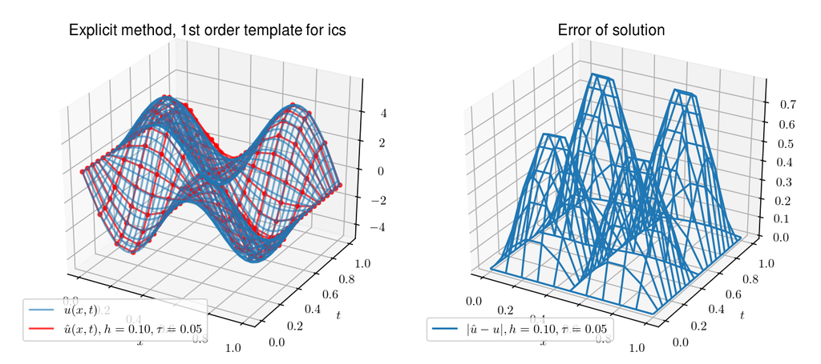

```python
fig1 = plot_solution(uu_expl1, xx, tt, u_true, 'Explicit', '1st order template')
```

Максимальная погрешность аппроксимации на каждом временном слое:

```python
Series(np.max(np.abs(uu_expl1 - u_true(xx, tt)), axis=1), index=t)
```

```
0.00    4.440892e-16
0.05    1.832225e-01
0.10    3.570473e-01
0.15    5.030782e-01
0.20    6.049758e-01
0.25    6.502605e-01
0.30    6.317824e-01
0.35    5.486875e-01
0.40    4.067624e-01
0.45    2.180963e-01
0.50    2.420653e-02
0.55    2.500948e-01
0.60    4.608949e-01
0.65    6.345099e-01
0.70    7.517828e-01
0.75    7.985731e-01
0.80    7.673900e-01
0.85    6.583961e-01
0.90    4.796596e-01
0.95    2.466040e-01
1.00    1.931359e-02
dtype: float64
```

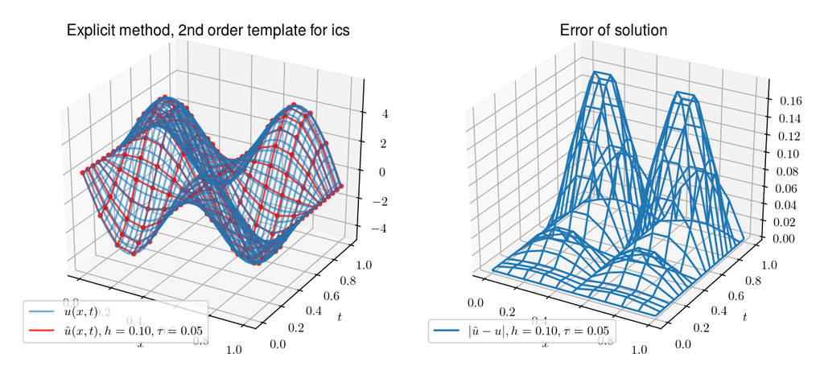

```python
fig2 = plot_solution(uu_expl2, xx, tt, u_true, 'Explicit', '2nd order template')
```

Максимальная погрешность аппроксимации на каждом временном слое:

```python
Series(np.max(np.abs(uu_expl2 - u_true(xx, tt)), axis=1), index=t)
```

```
0.00    4.440892e-16
0.05    6.531025e-03
0.10    4.483653e-03
0.15    4.605337e-03
0.20    1.638904e-02
0.25    2.728908e-02
0.30    3.334496e-02
0.35    3.128156e-02
0.40    1.908649e-02
0.45    5.118408e-03
0.50    3.686575e-02
0.55    7.427993e-02
0.60    1.126435e-01
0.65    1.463684e-01
0.70    1.697181e-01
0.75    1.776023e-01
0.80    1.663430e-01
0.85    1.343125e-01
0.90    8.235354e-02
0.95    1.391528e-02
1.00    6.734463e-02
dtype: float64
```

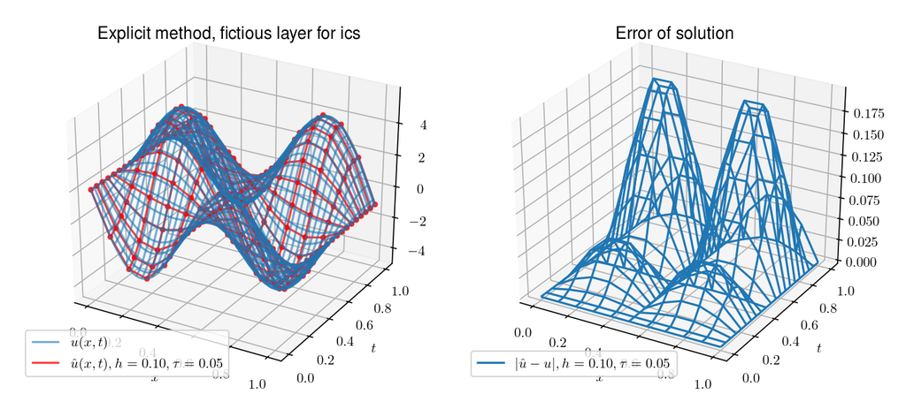

```python
fig3 = plot_solution(uu_expl3, xx, tt, u_true, 'Explicit', 'fictious layer')
```

Максимальная погрешность аппроксимации на каждом временном слое:

```python
Series(np.max(np.abs(uu_expl3 - u_true(xx, tt)), axis=1), index=t)
```

```
0.00    4.440892e-16
0.05    4.356254e-04
0.10    7.527871e-03
0.15    2.061888e-02
0.20    3.527824e-02
0.25    4.725016e-02
0.30    5.247182e-02
0.35    4.774774e-02
0.40    3.131961e-02
0.45    3.251053e-03
0.50    3.608745e-02
0.55    7.962956e-02
0.60    1.236102e-01
0.65    1.619050e-01
0.70    1.883409e-01
0.75    1.975330e-01
0.80    1.856784e-01
0.85    1.512063e-01
0.90    9.519245e-02
0.95    2.147331e-02
1.00    6.578920e-02
dtype: float64
```

### Сравнение результатов и выводы

Оценивать качество будем векторными (а именно, равномерной и непрерывной) нормами разностей каркасов точного и приближённого решения.

Погрешность явной схемы с аппроксимацией первого слоя с первым порядком:

```python
print("Среднеквадратичная: %.4f, равномерная: %.4f" %
      (np.linalg.norm(uu_expl1 - u_true(xx, tt)),
       np.max(np.abs(uu_expl1 - u_true(xx, tt)))))
```

```
Среднеквадратичная: 5.3450, равномерная: 0.7986
```

Погрешность явной схемы с аппроксимацией первого слоя со вторым порядком:

```python
print("Среднеквадратичная: %.4f, равномерная: %.4f" %
      (np.linalg.norm(uu_expl2 - u_true(xx, tt)),
       np.max(np.abs(uu_expl2 - u_true(xx, tt)))))
```

```
Среднеквадратичная: 0.9392, равномерная: 0.1776
```

Погрешность явной схемы с аппроксимацией первого слоя методом фиктивной точки:

```python
print("Среднеквадратичная: %.4f, равномерная: %.4f" %
      (np.linalg.norm(uu_expl3 - u_true(xx, tt)),
       np.max(np.abs(uu_expl3 - u_true(xx, tt)))))
```

```
Среднеквадратичная: 1.0564, равномерная: 0.1975
```

Как видим, в обеих нормах наилучшее приближение при использовании явной схемы получается при аппроксимации первого слоя со вторым порядком с учётом самого уравнения.